# Estimating *g* from Galileo’s Water Clock

A scientific Bayesian inverse problem with Stan and CmdStanPy

Author

Case study

Published

June 16, 2026

## 1 The experiment as an inverse problem

In the *Discorsi* (1638) Galileo timed a bronze ball rolling down a grooved inclined plane. Lacking a stopwatch, he measured elapsed time by **weighing the water** that drained from a vessel during each roll: the heavier the collected water, the longer the descent. By repeating the roll over marked fractions of the channel he established that distance grows with the *square* of time — the signature of constant acceleration.

Here we turn Galileo’s apparatus into a **Bayesian inverse problem**. The *forward model* maps an unknown physical parameter — the gravitational acceleration $g$ — to a predicted observation (a water mass). Given noisy measurements we *invert* the map to recover a posterior distribution over $g$, together with the unavoidable weighing noise $\sigma$.

## 2 The forward model

### 2.1 Mechanics of the rolling ball

A homogeneous sphere of mass $m$ and radius $\varrho$ rolls without slipping down a straight channel inclined at angle $\theta$ to the horizontal. Combining the translational and rotational equations of motion, the acceleration along the incline is

$$a \;=\; \frac{g\sin\theta}{1 + I/(m\varrho^{2})},$$

where $I$ is the moment of inertia about the ball’s centre. For a solid sphere $I = \tfrac{2}{5} m\varrho^{2}$, so the bracketed *rolling-inertia factor* is a pure number,

$$\kappa \;=\; 1 + \frac{I}{m\varrho^{2}} \;=\; \frac{7}{5},
\qquad\text{giving}\qquad
a \;=\; \frac{g\sin\theta}{\kappa}.$$

Starting from rest, the distance travelled obeys $d = \tfrac12 a t^{2}$, so the time to roll a distance $d$ is

$$t(d) \;=\; \sqrt{\frac{2d}{a}} \;=\; \sqrt{\frac{2\kappa\,d}{g\sin\theta}}.$$

### 2.2 The water clock

While the ball rolls, water escapes the clock at an (approximately) constant mass-flow rate $r$ (grams per second). The **collected water mass is the observable proxy for time**:

$$w(d) \;=\; r\,t(d) \;=\; r\,\sqrt{\frac{2\kappa\,d}{g\sin\theta}}.$$

This is our forward operator $\mathcal{F}_g : d \mapsto w$.

### 2.3 An identifiability remark

Rewriting $w(d) = \dfrac{r}{\sqrt{g}}\sqrt{\dfrac{2\kappa d}{\sin\theta}}$ shows that $g$ and $r$ enter **only through the ratio $r/\sqrt{g}$**. With the flow rate unknown, the data constrain just the combination $r^{2}/g$, not $g$ alone. We therefore treat $r$ as **calibrated** — exactly as Galileo would have done by weighing the steady outflow over a measured interval — which makes $g$ identifiable. The geometry $\theta$ and the constant $\kappa$ are likewise taken as known.

## 3 The statistical model

We observe water masses $w_1,\dots,w_N$ at design distances $d_1,\dots,d_N$. Weighing introduces additive error, giving the sampling distribution

$$w_i \;\sim\; \operatorname{Normal}\!\bigl(\mu_i,\;\sigma\bigr),
\qquad
\mu_i \;=\; r\,\sqrt{\frac{2\kappa\,d_i}{g\,\sin\theta}}.$$

We complete the model with weakly-informative, positively-constrained priors

$$g \;\sim\; \operatorname{Normal}^{+}(10,\,5),
\qquad
\sigma \;\sim\; \operatorname{Normal}^{+}(0,\,5),$$

so that the prior on $g$ spans a generous range (its standard deviation of $5\,\mathrm{m\,s^{-2}}$ comfortably covers any plausible terrestrial value) and the data, rather than the prior, drive the posterior.

## 4 The Stan program

The model below implements the forward operator and likelihood directly. We write it to `galileo.stan`, which CmdStanPy compiles in the next section.

```python
stan_code = r"""
data {
  int<lower=1> N;                    // number of rolls
  vector<lower=0>[N] d;              // distance rolled along the incline (m)
  vector<lower=0>[N] w;              // water mass collected (g)  -- the data
  real<lower=0> r;                   // calibrated water flow rate (g / s)
  real<lower=0> kappa;               // rolling-inertia factor (7/5 for a solid sphere)
  real<lower=0, upper=1> sin_theta;  // sine of the incline angle
}
parameters {
  real<lower=0> g;                   // gravitational acceleration (m / s^2)
  real<lower=0> sigma;               // weighing noise (g)
}
model {
  // Forward model: predicted water mass at each distance.
  vector[N] mu = r * sqrt(2 * kappa * d / (g * sin_theta));

  // Weakly-informative priors (positivity from the <lower=0> declarations).
  g     ~ normal(10, 5);
  sigma ~ normal(0, 5);

  // Likelihood.
  w ~ normal(mu, sigma);
}
"""

with open("galileo.stan", "w") as f:
    f.write(stan_code)
```

## 5 Simulating the experiment

We generate synthetic data from known “true” parameters so we can check that the inversion recovers them. In practice the `w` column would instead come from the laboratory scale.

```python
import numpy as np
import pandas as pd
import plotnine as pn
from cmdstanpy import CmdStanModel

rng = np.random.default_rng(2024)

# --- "True" parameters (hidden from the model) -------------------------------
g_true     = 9.81      # gravitational acceleration (m / s^2)
sigma_true = 3.0       # weighing noise (g)

# --- Known / calibrated experimental constants -------------------------------
r          = 50.0      # water flow rate (g / s), calibrated separately
kappa      = 7.0 / 5.0 # solid-sphere rolling-inertia factor
sin_theta  = 0.10      # sine of the incline angle (~5.7 degrees)

# --- Experimental design: marked distances, each rolled several times --------
distances  = np.array([1.0, 2.0, 3.0, 4.0, 5.0])
reps       = 5
d          = np.repeat(distances, reps)
N          = d.size

# --- Forward simulation of the water-clock observations ----------------------
mu = r * np.sqrt(2 * kappa * d / (g_true * sin_theta))
w  = mu + rng.normal(0.0, sigma_true, size=N)

sim = pd.DataFrame({"d": d, "w": w, "mu": mu})
```

The simulated measurements scatter about the $w \propto \sqrt{d}$ forward curve:

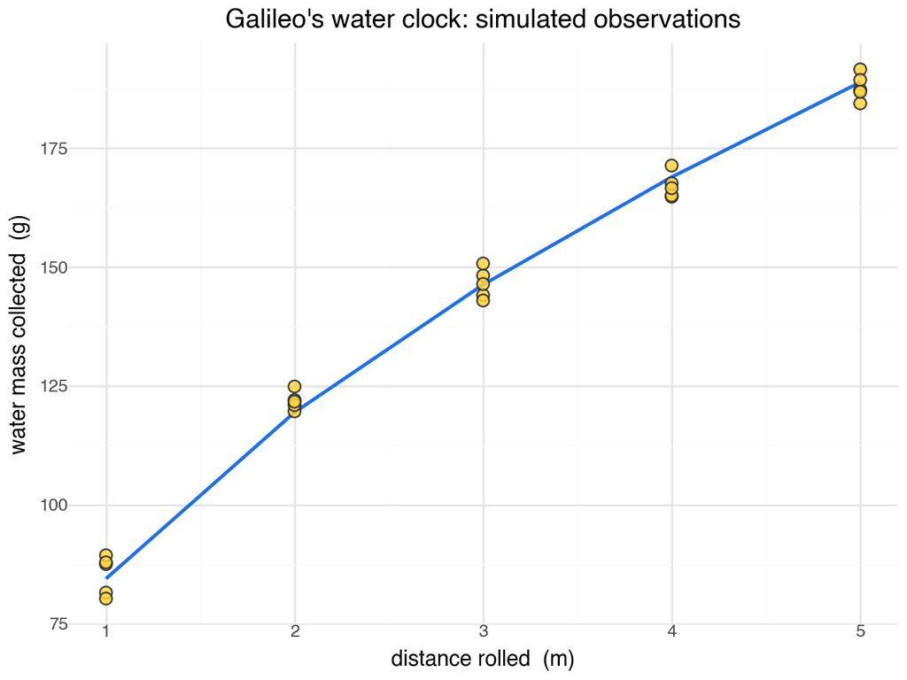

Figure 1: Simulated water-clock measurements (points) against the noise-free forward model (curve).

```python
(
    pn.ggplot(sim, pn.aes("d", "w"))
    + pn.geom_line(pn.aes(y="mu"), color="#1f6feb", size=1)
    + pn.geom_point(color="#24292f", fill="#ffd33d", size=3, alpha=0.85)
    + pn.labs(
        x="distance rolled  (m)",
        y="water mass collected  (g)",
        title="Galileo's water clock: simulated observations",
    )
    + pn.theme_minimal()
)
```

## 6 Fitting the inverse problem

We assemble the data dictionary, compile the Stan program, and draw posterior samples with the no-U-turn sampler.

```python
stan_data = {
    "N": N,
    "d": d.tolist(),
    "w": w.tolist(),
    "r": r,
    "kappa": kappa,
    "sin_theta": sin_theta,
}

model = CmdStanModel(stan_file="galileo.stan")

fit = model.sample(
    data=stan_data,
    chains=4,
    parallel_chains=4,
    iter_warmup=1000,
    iter_sampling=1000,
    seed=2024,
    show_progress=False,
)
```

The posterior summary — the deliverable for this stage — reports the marginal posterior for $g$ and $\sigma$ alongside MCMC diagnostics (`R_hat`, effective sample sizes). The posterior mean for `g` should sit close to the true $9.81\ \mathrm{m\,s^{-2}}$.

```python
fit.summary()
```

|  | Mean | MCSE | StdDev | MAD | 5% | 50% | 95% | ESS_bulk | ESS_tail | ESS_bulk/s | R_hat |
| --- | --- | --- | --- | --- | --- | --- | --- | --- | --- | --- | --- |
| lp__ | -38.23850 | 0.025380 | 1.033510 | 0.758354 | -40.28640 | -37.92610 | -37.24740 | 1770.70 | 2219.25 | 38493.6 | 1.00163 |
| g | 9.83438 | 0.001801 | 0.089134 | 0.087850 | 9.68823 | 9.83327 | 9.98624 | 2473.11 | 2118.62 | 53763.2 | 1.00197 |
| sigma | 3.27127 | 0.010146 | 0.498258 | 0.484397 | 2.56898 | 3.20371 | 4.16179 | 2556.25 | 2558.40 | 55570.7 | 1.00076 |

## 7 Where this goes next

This scaffold isolates the core inversion. Natural extensions, each a short addition to the Stan program and a `plotnine` figure, include: posterior predictive checks via a `generated quantities` block of `w_rep`; propagating calibration uncertainty by promoting $r$ to a parameter with an informative prior (recall the Section 2.3 degeneracy); a multiplicative (log-normal) noise model; and jointly inferring the incline angle $\theta$ from auxiliary measurements.

**Note**

**Prerequisites.** Render with `quarto render galileo.qmd`. You will need `pip install cmdstanpy plotnine jupyter`, a one-time CmdStan install (`python -c "import cmdstanpy; cmdstanpy.install_cmdstan()"`), and a working C++ toolchain.